# Introduction to padr

Rick Dean

09/05/2020

```r
library(knitr)
library(padr)
library(data.table)
library(ggplot2)
library(magrittr)
```

## 1.1 Introduction

The following scripts are from padr’s vignette [Introduction to padr](https://cran.r-project.org/web/packages/padr/vignettes/padr.html).

## 1.2 Modify the coffee data set time stamp in steps

1. Set coffee data set as data.table:

```r
coffee_dt <- data.table::setDT(padr::coffee)
head(coffee_dt)
```

```
##             time_stamp amount
## 1: 2016-07-07 03:11:21   3.14
## 2: 2016-07-07 03:46:48   2.98
## 3: 2016-07-09 07:25:17   4.11
## 4: 2016-07-10 04:45:11   3.14
```

2. Thicken the *time_stamp* variable to a higher interval of “day”:

```r
new_coffee_dt <- coffee_dt %>%
  padr::thicken(interval = "day")
head(new_coffee_dt)
```

```
##             time_stamp amount time_stamp_day
## 1: 2016-07-07 03:11:21   3.14     2016-07-07
## 2: 2016-07-07 03:46:48   2.98     2016-07-07
## 3: 2016-07-09 07:25:17   4.11     2016-07-09
## 4: 2016-07-10 04:45:11   3.14     2016-07-10
```

3. Pad the *time_stamp_day* variable by filling in missing days:

```r
new_coffee_dt <- new_coffee_dt %>%
  padr::pad(by = "time_stamp_day")
head(new_coffee_dt)
```

```
##             time_stamp amount time_stamp_day
## 1: 2016-07-07 03:11:21   3.14     2016-07-07
## 2: 2016-07-07 03:46:48   2.98     2016-07-07
## 3:                <NA>     NA     2016-07-08
## 4: 2016-07-09 07:25:17   4.11     2016-07-09
## 5: 2016-07-10 04:45:11   3.14     2016-07-10
```

4. Fill the NA observations with values:

```r
new_coffee_dt <- new_coffee_dt %>%
  padr::fill_by_value(amount, value = 0)
head(new_coffee_dt)
```

```
##             time_stamp amount time_stamp_day
## 1: 2016-07-07 03:11:21   3.14     2016-07-07
## 2: 2016-07-07 03:46:48   2.98     2016-07-07
## 3:                <NA>   0.00     2016-07-08
## 4: 2016-07-09 07:25:17   4.11     2016-07-09
## 5: 2016-07-10 04:45:11   3.14     2016-07-10
```

5. Group *time_stamp_day* variable and aggregate by adding a sum variable:

```r
new_coffee_grouped_dt <- new_coffee_dt[,.(day_amount = sum(amount)),by = .(time_stamp_day)]
head(new_coffee_grouped_dt)
```

```
##    time_stamp_day day_amount
## 1:     2016-07-07       6.12
## 2:     2016-07-08       0.00
## 3:     2016-07-09       4.11
## 4:     2016-07-10       3.14
```

6. Plot the data:

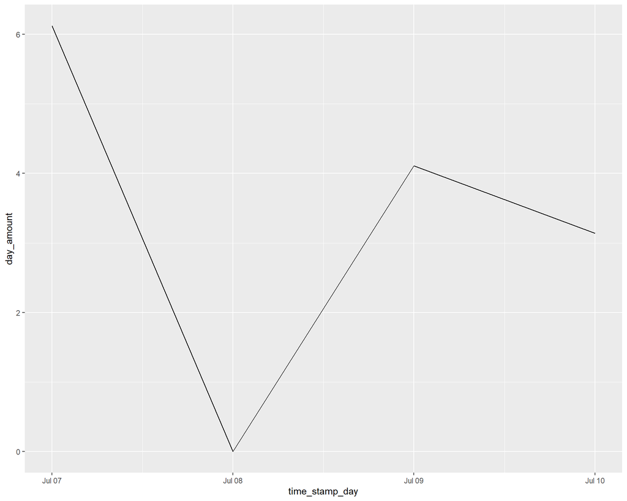

```r
ggplot(data = new_coffee_grouped_dt, aes(x = time_stamp_day, y = day_amount)) +
  geom_line()
```

## 1.3 Specify interval with thicken

1. Set up the data set:

```r
day_data_dt <- data.table(day_var = as.Date(c("2016-08-12", "2016-08-13", "2016-08-26", "2016-08-29")))
head(day_data_dt)
```

```
##       day_var
## 1: 2016-08-12
## 2: 2016-08-13
## 3: 2016-08-26
## 4: 2016-08-29
```

2. Thicken with interval = “week”:

```r
week_data_dt <- day_data_dt %>%
  padr::thicken(interval = "week")
head(week_data_dt)
```

```
##       day_var day_var_week
## 1: 2016-08-12   2016-08-07
## 2: 2016-08-13   2016-08-07
## 3: 2016-08-26   2016-08-21
## 4: 2016-08-29   2016-08-28
```

3. Thicken with interval = “4 days”

```r
four_day_data_dt <- day_data_dt %>%
  padr::thicken(interval = "4 days")
head(four_day_data_dt)
```

```
##       day_var day_var_4_day
## 1: 2016-08-12    2016-08-11
## 2: 2016-08-13    2016-08-11
## 3: 2016-08-26    2016-08-23
## 4: 2016-08-29    2016-08-27
```

### 1.3.1 Further refinement using thicken’s start_val

1. Set up the data set:

```r
emergency_dt <- data.table::setDT(padr::emergency)
head(emergency_dt)
```

```
##         lat       lng   zip                   title          time_stamp
## 1: 40.29788 -75.58129 19525  EMS: BACK PAINS/INJURY 2015-12-10 17:40:00
## 2: 40.25806 -75.26468 19446 EMS: DIABETIC EMERGENCY 2015-12-10 17:40:00
## 3: 40.12118 -75.35198 19401     Fire: GAS-ODOR/LEAK 2015-12-10 17:40:00
## 4: 40.11615 -75.34351 19401  EMS: CARDIAC EMERGENCY 2015-12-10 17:40:01
## 5: 40.25149 -75.60335    NA          EMS: DIZZINESS 2015-12-10 17:40:01
## 6: 40.25347 -75.28324 19446        EMS: HEAD INJURY 2015-12-10 17:40:01
##                  twp
## 1:       NEW HANOVER
## 2: HATFIELD TOWNSHIP
## 3:        NORRISTOWN
## 4:        NORRISTOWN
## 5:  LOWER POTTSGROVE
## 6:          LANSDALE
```

2. Filter by title:

```r
emergency_overdose_dt <- emergency_dt[title == "EMS: OVERDOSE"]
head(emergency_overdose_dt)
```

```
##         lat       lng   zip         title          time_stamp              twp
## 1: 40.15090 -75.12744 19090 EMS: OVERDOSE 2015-12-10 22:32:01   UPPER MORELAND
## 2: 40.15583 -75.36521 19403 EMS: OVERDOSE 2015-12-11 17:07:01    EAST NORRITON
## 3: 40.00971 -75.29040 19003 EMS: OVERDOSE 2015-12-12 16:52:01     LOWER MERION
## 4: 40.15090 -75.12744 19090 EMS: OVERDOSE 2015-12-12 19:07:01   UPPER MORELAND
## 5: 40.31629 -75.55367 18074 EMS: OVERDOSE 2015-12-12 19:57:01      NEW HANOVER
## 6: 40.11121 -75.42619 19403 EMS: OVERDOSE 2015-12-13 00:27:01 LOWER PROVIDENCE
```

3. Thicken with *interval* = “day” and *start_val* = “2015-12-11 08:00:00”:

```r
emergency_overdose_dt <- emergency_overdose_dt %>%
  padr::thicken(
    interval = "day",
    start_val = as.POSIXct("2015-12-11 08:00:00", tz="EST"),
    colname = "daystart"
  )
head(emergency_overdose_dt, n = 10)
```

```
##          lat       lng   zip         title          time_stamp              twp
##  1: 40.15583 -75.36521 19403 EMS: OVERDOSE 2015-12-11 17:07:01    EAST NORRITON
##  2: 40.00971 -75.29040 19003 EMS: OVERDOSE 2015-12-12 16:52:01     LOWER MERION
##  3: 40.15090 -75.12744 19090 EMS: OVERDOSE 2015-12-12 19:07:01   UPPER MORELAND
##  4: 40.31629 -75.55367 18074 EMS: OVERDOSE 2015-12-12 19:57:01      NEW HANOVER
##  5: 40.11121 -75.42619 19403 EMS: OVERDOSE 2015-12-13 00:27:01 LOWER PROVIDENCE
##  6: 40.11121 -75.42619 19403 EMS: OVERDOSE 2015-12-13 00:28:00 LOWER PROVIDENCE
##  7: 40.24730 -75.65523 19464 EMS: OVERDOSE 2015-12-13 03:16:01        POTTSTOWN
##  8: 40.14148 -75.11714 19090 EMS: OVERDOSE 2015-12-13 13:46:01         ABINGTON
##  9: 40.14279 -75.11960 19090 EMS: OVERDOSE 2015-12-13 13:47:00         ABINGTON
## 10: 40.11621 -75.12075 19001 EMS: OVERDOSE 2015-12-13 14:32:00         ABINGTON
##                daystart
##  1: 2015-12-11 08:00:00
##  2: 2015-12-12 08:00:00
##  3: 2015-12-12 08:00:00
##  4: 2015-12-12 08:00:00
##  5: 2015-12-12 08:00:00
##  6: 2015-12-12 08:00:00
##  7: 2015-12-12 08:00:00
##  8: 2015-12-13 08:00:00
##  9: 2015-12-13 08:00:00
## 10: 2015-12-13 08:00:00
```

4. Group by daystart and get a count for each day:

```r
emergency_overdose_grouped_dt <- emergency_overdose_dt[, .(nr_od = .N), by = .(daystart)]
head(emergency_overdose_grouped_dt)
```

```
##               daystart nr_od
## 1: 2015-12-11 08:00:00     1
## 2: 2015-12-12 08:00:00     6
## 3: 2015-12-13 08:00:00     7
## 4: 2015-12-14 08:00:00     8
## 5: 2015-12-15 08:00:00     1
## 6: 2015-12-16 08:00:00     4
```

## 1.4 Specify pad

1. Set up the data set:

```r
account_data_dt <- data.table(day = as.Date(c("2016-10-21", "2016-10-23", "2016-10-26")),
                           balance = c(304.46, 414.76, 378.98))
head(account_data_dt)
```

```
##           day balance
## 1: 2016-10-21  304.46
## 2: 2016-10-23  414.76
## 3: 2016-10-26  378.98
```

2. Apply *pad()* with interval of day:

```r
account_data_padded_dt <- account_data_dt %>%
  pad()
head(account_data_padded_dt)
```

```
##           day balance
## 1: 2016-10-21  304.46
## 2: 2016-10-22      NA
## 3: 2016-10-23  414.76
## 4: 2016-10-24      NA
## 5: 2016-10-25      NA
## 6: 2016-10-26  378.98
```

3. Fill NA’s with last value:

```r
data.table::setnafill(account_data_padded_dt, type = "locf", cols = "balance")
head(account_data_padded_dt)
```

```
##           day balance
## 1: 2016-10-21  304.46
## 2: 2016-10-22  304.46
## 3: 2016-10-23  414.76
## 4: 2016-10-24  414.76
## 5: 2016-10-25  414.76
## 6: 2016-10-26  378.98
```

4. Specify a lower interval than the one of the variable, using *pad* as the inverse of *thicken*:

```r
account_data_hour_dt <- account_data_dt %>%
  padr::pad(interval = "hour", start_val = as.POSIXct("2016-10-20 22:00:00"))
head(account_data_hour_dt)
```

```
##                    day balance
## 1: 2016-10-20 22:00:00      NA
## 2: 2016-10-20 23:00:00      NA
## 3: 2016-10-21 00:00:00  304.46
## 4: 2016-10-21 01:00:00      NA
## 5: 2016-10-21 02:00:00      NA
## 6: 2016-10-21 03:00:00      NA
```

### 1.4.1 Using the grouping argument of *pad*

1. Set up the data set:

```r
grouping_dt <- data.table(
  group = rep(c("A","B"), c(3,3)),
  date = as.Date(c("2017-10-02", "2017-10-04", "2017-10-06", "2017-10-01", "2017-10-03", "2017-10-04")),
  value = rep(2,6)
)
head(grouping_dt)
```

```
##    group       date value
## 1:     A 2017-10-02     2
## 2:     A 2017-10-04     2
## 3:     A 2017-10-06     2
## 4:     B 2017-10-01     2
## 5:     B 2017-10-03     2
## 6:     B 2017-10-04     2
```

2. Use *pad()* to group with an interval of “day”:

```r
grouping_dt <- grouping_dt %>%
  pad(group = "group")
head(grouping_dt, n = 10)
```

```
##    group       date value
## 1:     A 2017-10-02     2
## 2:     A 2017-10-03    NA
## 3:     A 2017-10-04     2
## 4:     A 2017-10-05    NA
## 5:     A 2017-10-06     2
## 6:     B 2017-10-01     2
## 7:     B 2017-10-02    NA
## 8:     B 2017-10-03     2
## 9:     B 2017-10-04     2
```

### 1.4.2 Using fill functions with *pad*

1. Set up the data set:

```r
counts_dt <- data.table(x = as.Date(c("2016-11-21", "2016-11-23", "2016-11-24")), y = c(2, 4, 4))
head(counts_dt)
```

```
##             x y
## 1: 2016-11-21 2
## 2: 2016-11-23 4
## 3: 2016-11-24 4
```

2. Apply pad and fill NA’s (note: interval for *pad()* is “day” and default value is 0):

```r
counts_filled_dt <- counts_dt %>%
  padr::pad() %>%
  padr::fill_by_value(y)
head(counts_filled_dt)
```

```
##             x y
## 1: 2016-11-21 2
## 2: 2016-11-22 0
## 3: 2016-11-23 4
## 4: 2016-11-24 4
```

3. Fill with a specific value = 42:

```r
counts_filled_dt <- counts_dt %>%
  padr::pad() %>%
  padr::fill_by_value(y,value = 42)
head(counts_filled_dt)
```

```
##             x  y
## 1: 2016-11-21  2
## 2: 2016-11-22 42
## 3: 2016-11-23  4
## 4: 2016-11-24  4
```

4. Fill with the function *mean()*:

```r
counts_filled_dt <- counts_dt %>%
  padr::pad() %>%
  padr::fill_by_function(y,fun = mean)
head(counts_filled_dt)
```

```
##             x        y
## 1: 2016-11-21 2.000000
## 2: 2016-11-22 3.333333
## 3: 2016-11-23 4.000000
## 4: 2016-11-24 4.000000
```

5. Fill by prevalence:

```r
counts_filled_dt <- counts_dt %>%
  padr::pad() %>%
  padr::fill_by_prevalent(y)
head(counts_filled_dt)
```

```
##             x y
## 1: 2016-11-21 2
## 2: 2016-11-22 4
## 3: 2016-11-23 4
## 4: 2016-11-24 4
```

## 1.5 Formatting functions

### 1.5.1 Using *center_interval()*

1. Set up the data set:

```r
emergency_dt <- data.table::setDT(padr::emergency)
head(emergency_dt)
```

```
##         lat       lng   zip                   title          time_stamp
## 1: 40.29788 -75.58129 19525  EMS: BACK PAINS/INJURY 2015-12-10 17:40:00
## 2: 40.25806 -75.26468 19446 EMS: DIABETIC EMERGENCY 2015-12-10 17:40:00
## 3: 40.12118 -75.35198 19401     Fire: GAS-ODOR/LEAK 2015-12-10 17:40:00
## 4: 40.11615 -75.34351 19401  EMS: CARDIAC EMERGENCY 2015-12-10 17:40:01
## 5: 40.25149 -75.60335    NA          EMS: DIZZINESS 2015-12-10 17:40:01
## 6: 40.25347 -75.28324 19446        EMS: HEAD INJURY 2015-12-10 17:40:01
##                  twp
## 1:       NEW HANOVER
## 2: HATFIELD TOWNSHIP
## 3:        NORRISTOWN
## 4:        NORRISTOWN
## 5:  LOWER POTTSGROVE
## 6:          LANSDALE
```

2. Thicken *time_stamp* to a higher interval of “hour”:

```r
emergency_dt <- emergency_dt %>%
  padr::thicken(interval = "hour", colname = "h")
head(emergency_dt)
```

```
##         lat       lng   zip                   title          time_stamp
## 1: 40.29788 -75.58129 19525  EMS: BACK PAINS/INJURY 2015-12-10 17:40:00
## 2: 40.25806 -75.26468 19446 EMS: DIABETIC EMERGENCY 2015-12-10 17:40:00
## 3: 40.12118 -75.35198 19401     Fire: GAS-ODOR/LEAK 2015-12-10 17:40:00
## 4: 40.11615 -75.34351 19401  EMS: CARDIAC EMERGENCY 2015-12-10 17:40:01
## 5: 40.25149 -75.60335    NA          EMS: DIZZINESS 2015-12-10 17:40:01
## 6: 40.25347 -75.28324 19446        EMS: HEAD INJURY 2015-12-10 17:40:01
##                  twp                   h
## 1:       NEW HANOVER 2015-12-10 17:00:00
## 2: HATFIELD TOWNSHIP 2015-12-10 17:00:00
## 3:        NORRISTOWN 2015-12-10 17:00:00
## 4:        NORRISTOWN 2015-12-10 17:00:00
## 5:  LOWER POTTSGROVE 2015-12-10 17:00:00
## 6:          LANSDALE 2015-12-10 17:00:00
```

3. Count the number in each hour:

```r
emergency_hour_count_dt <- emergency_dt[, .(hour_count = .N), by = .(h)]
head(emergency_hour_count_dt)
```

```
##                      h hour_count
## 1: 2015-12-10 17:00:00         22
## 2: 2015-12-10 18:00:00         28
## 3: 2015-12-10 19:00:00         22
## 4: 2015-12-10 20:00:00         15
## 5: 2015-12-10 21:00:00          9
## 6: 2015-12-10 22:00:00         12
```

4. Take the first 24 hours and create a new variable that centers the hours using *center_interval()*:

```r
emergency_hour_count_dt[1:24, h_center := padr::center_interval(h)]
head(emergency_hour_count_dt)
```

```
##                      h hour_count            h_center
## 1: 2015-12-10 17:00:00         22 2015-12-10 17:30:00
## 2: 2015-12-10 18:00:00         28 2015-12-10 18:30:00
## 3: 2015-12-10 19:00:00         22 2015-12-10 19:30:00
## 4: 2015-12-10 20:00:00         15 2015-12-10 20:30:00
## 5: 2015-12-10 21:00:00          9 2015-12-10 21:30:00
## 6: 2015-12-10 22:00:00         12 2015-12-10 22:30:00
```

5. Plot on the centered hours:

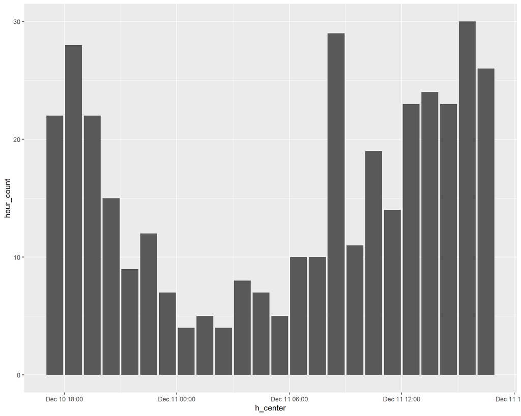

```r
ggplot(data = emergency_hour_count_dt, aes(x = h_center, y = hour_count)) +
  geom_bar(stat = "identity")
```

The bars are now between the hours, rather than on the hours.

### 1.5.2 Using *format_interval()*

1. Set up the data set:

```r
emergency_dt <- data.table::setDT(padr::emergency)
emergency_head_dt <- emergency_dt[title == "EMS: HEAD INJURY"]
head(emergency_head_dt)
```

```
##         lat       lng   zip            title          time_stamp          twp
## 1: 40.25347 -75.28324 19446 EMS: HEAD INJURY 2015-12-10 17:40:01     LANSDALE
## 2: 40.15528 -75.26423 19422 EMS: HEAD INJURY 2015-12-10 18:06:25     WHITPAIN
## 3: 40.29527 -75.32840 18964 EMS: HEAD INJURY 2015-12-10 20:12:02    FRANCONIA
## 4: 40.08820 -75.32664 19406 EMS: HEAD INJURY 2015-12-11 00:57:01 UPPER MERION
## 5: 40.26418 -75.65600 19464 EMS: HEAD INJURY 2015-12-11 04:02:01    POTTSTOWN
## 6: 40.01177 -75.29467 19041 EMS: HEAD INJURY 2015-12-11 04:17:01 LOWER MERION
```

2. Raise the time interval to “6 hour”:

```r
emergency_head_dt <- emergency_head_dt %>%
  padr::thicken(interval = "6 hour", colname = "hour6")
head(emergency_head_dt)
```

```
##         lat       lng   zip            title          time_stamp          twp
## 1: 40.25347 -75.28324 19446 EMS: HEAD INJURY 2015-12-10 17:40:01     LANSDALE
## 2: 40.15528 -75.26423 19422 EMS: HEAD INJURY 2015-12-10 18:06:25     WHITPAIN
## 3: 40.29527 -75.32840 18964 EMS: HEAD INJURY 2015-12-10 20:12:02    FRANCONIA
## 4: 40.08820 -75.32664 19406 EMS: HEAD INJURY 2015-12-11 00:57:01 UPPER MERION
## 5: 40.26418 -75.65600 19464 EMS: HEAD INJURY 2015-12-11 04:02:01    POTTSTOWN
## 6: 40.01177 -75.29467 19041 EMS: HEAD INJURY 2015-12-11 04:17:01 LOWER MERION
##                  hour6
## 1: 2015-12-10 12:00:00
## 2: 2015-12-10 18:00:00
## 3: 2015-12-10 18:00:00
## 4: 2015-12-11 00:00:00
## 5: 2015-12-11 00:00:00
## 6: 2015-12-11 00:00:00
```

3. Count the number in each 6 hour interval:

```r
emergency_head_count_dt <- emergency_head_dt[, .(six_hour_count = .N), by = .(hour6)]
head(emergency_head_count_dt)
```

```
##                  hour6 six_hour_count
## 1: 2015-12-10 12:00:00              1
## 2: 2015-12-10 18:00:00              2
## 3: 2015-12-11 00:00:00              3
## 4: 2015-12-11 12:00:00              8
## 5: 2015-12-11 18:00:00              2
## 6: 2015-12-12 00:00:00              2
```

4. Pad with missing times and fill NA’s with 0:

```r
emergency_head_count_dt <- emergency_head_count_dt %>%
  pad() %>%
  fill_by_value()
head(emergency_head_count_dt)
```

```
##                  hour6 six_hour_count
## 1: 2015-12-10 12:00:00              1
## 2: 2015-12-10 18:00:00              2
## 3: 2015-12-11 00:00:00              3
## 4: 2015-12-11 06:00:00              0
## 5: 2015-12-11 12:00:00              8
## 6: 2015-12-11 18:00:00              2
```

5. Add variable “hours6_fmt” showing a new time format:

```r
emergency_head_count_dt[, hours6_fmt := padr::format_interval(x = hour6, start_format = "%Hh", sep = "-")]
head(emergency_head_count_dt)
```

```
##                  hour6 six_hour_count hours6_fmt
## 1: 2015-12-10 12:00:00              1    12h-18h
## 2: 2015-12-10 18:00:00              2    18h-00h
## 3: 2015-12-11 00:00:00              3    00h-06h
## 4: 2015-12-11 06:00:00              0    06h-12h
## 5: 2015-12-11 12:00:00              8    12h-18h
## 6: 2015-12-11 18:00:00              2    18h-00h
```

6. Plot the data:

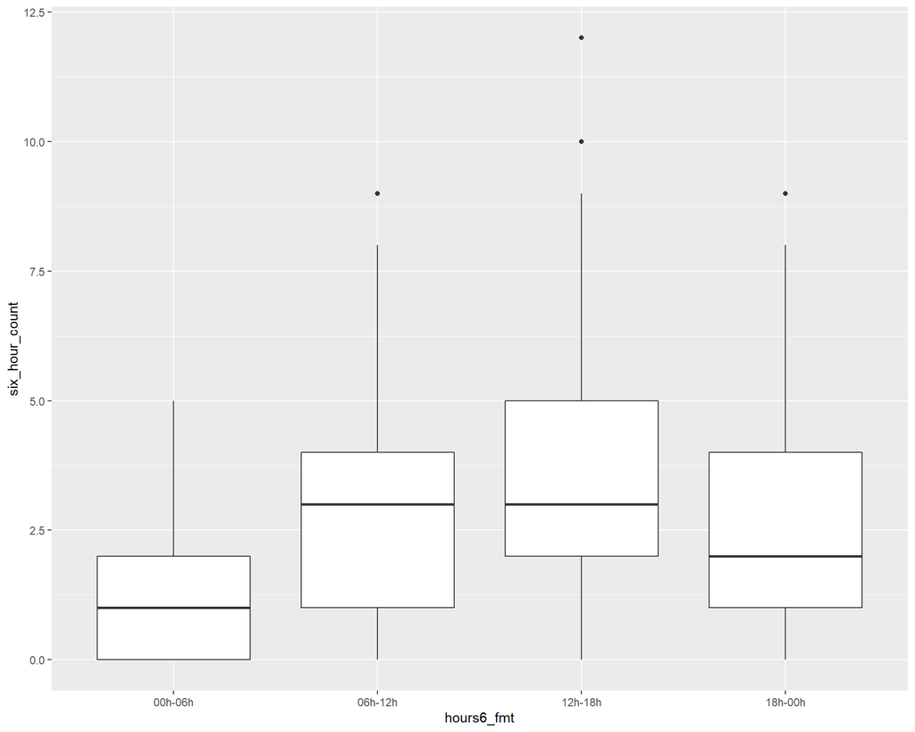

```r
ggplot(data = emergency_head_count_dt, aes(x = hours6_fmt, y = six_hour_count)) +
  geom_boxplot()
```